# Chicago Taxi Fare Prediction

Taxi 데이터를 활용하여 주행거리(`TRIP_MILES`)와 주행시간(`TRIP_SECONDS`)에 따른 요금(`FARE`)을 선형회귀로 예측하고 성능을 비교한다.

## 분석 목표

1. `TRIP_MILES`와 `FARE` 사이의 관계를 산점도로 확인한다.
2. `TRIP_SECONDS`와 `FARE` 사이의 관계를 산점도로 확인한다.
3. `TRIP_MILES`만 사용한 단순 선형회귀 모델을 학습한다.
4. `TRIP_SECONDS`만 사용한 단순 선형회귀 모델을 학습한다.
5. `TRIP_MILES`와 `TRIP_SECONDS`를 동시에 사용한 다중 선형회귀 모델을 학습한다.
6. 각 모델의 가중치(weight), 편향(bias), RMSE를 비교한다.
7. Correlation Matrix와 VIF를 통해 다중공선성 가능성을 해석한다.

```python
# =========================
# 1. 라이브러리 불러오기
# =========================

import pandas as pd
import numpy as np
import matplotlib.pyplot as plt

from sklearn.model_selection import train_test_split
from sklearn.linear_model import LinearRegression
from sklearn.metrics import mean_squared_error

plt.rcParams["figure.figsize"] = (8, 5)
plt.rcParams["axes.grid"] = True
plt.rcParams["font.size"] = 11
```

```python
# =========================
# 2. 데이터 불러오기
# =========================

df = pd.read_csv("chicago_taxi_train.csv")

print("데이터 크기:", df.shape)
display(df.head())

print("\n컬럼 목록")
print(df.columns.tolist())
```

```
데이터 크기: (31694, 18)
```

|  | TRIP_START_TIMESTAMP | TRIP_END_TIMESTAMP | TRIP_START_HOUR | TRIP_SECONDS | TRIP_MILES | TRIP_SPEED | PICKUP_CENSUS_TRACT | DROPOFF_CENSUS_TRACT | PICKUP_COMMUNITY_AREA | DROPOFF_COMMUNITY_AREA | FARE | TIPS | TIP_RATE | TOLLS | EXTRAS | TRIP_TOTAL | PAYMENT_TYPE | COMPANY |
| --- | --- | --- | --- | --- | --- | --- | --- | --- | --- | --- | --- | --- | --- | --- | --- | --- | --- | --- |
| 0 | 05/17/2022 7:15:00 AM | 05/17/2022 7:45:00 AM | 7.25 | 2341 | 2.57 | 4.0 | NaN | NaN | NaN | 17.0 | 31.99 | 2.0 | 6.3 | 0.0 | 0.0 | 33.99 | Mobile | Flash Cab |
| 1 | 05/17/2022 5:15:00 PM | 05/17/2022 5:30:00 PM | 17.25 | 1074 | 1.18 | 4.0 | NaN | 1.703108e+10 | NaN | 8.0 | 9.75 | 3.0 | 27.9 | 0.0 | 1.0 | 14.25 | Credit Card | Flash Cab |
| 2 | 05/17/2022 5:15:00 PM | 05/17/2022 5:30:00 PM | 17.25 | 1173 | 1.29 | 4.0 | 1.703132e+10 | 1.703108e+10 | 32.0 | 8.0 | 10.25 | 0.0 | 0.0 | 0.0 | 0.0 | 10.25 | Cash | Sun Taxi |
| 3 | 05/17/2022 6:00:00 PM | 05/17/2022 7:00:00 PM | 18.00 | 3360 | 3.70 | 4.0 | 1.703132e+10 | 1.703124e+10 | 32.0 | 24.0 | 23.75 | 0.0 | 0.0 | 0.0 | 1.0 | 24.75 | Cash | Choice Taxi Association |
| 4 | 05/17/2022 5:00:00 PM | 05/17/2022 5:30:00 PM | 17.00 | 1044 | 1.15 | 4.0 | 1.703132e+10 | 1.703108e+10 | 32.0 | 8.0 | 10.00 | 0.0 | 0.0 | 0.0 | 0.0 | 10.00 | Cash | Flash Cab |

```
컬럼 목록
['TRIP_START_TIMESTAMP', 'TRIP_END_TIMESTAMP', 'TRIP_START_HOUR', 'TRIP_SECONDS', 'TRIP_MILES', 'TRIP_SPEED', 'PICKUP_CENSUS_TRACT', 'DROPOFF_CENSUS_TRACT', 'PICKUP_COMMUNITY_AREA', 'DROPOFF_COMMUNITY_AREA', 'FARE', 'TIPS', 'TIP_RATE', 'TOLLS', 'EXTRAS', 'TRIP_TOTAL', 'PAYMENT_TYPE', 'COMPANY']
```

```python
# =========================
# 3. 필요한 컬럼 선택 및 전처리
# =========================

cols = ["TRIP_MILES", "TRIP_SECONDS", "FARE"]
taxi = df[cols].copy()

print("결측치 개수")
print(taxi.isnull().sum())

# 결측치 제거
taxi = taxi.dropna()

# 거리, 시간, 요금이 0 이하인 데이터는 회귀 분석에 부적절하므로 제거
taxi = taxi[
    (taxi["TRIP_MILES"] > 0) &
    (taxi["TRIP_SECONDS"] > 0) &
    (taxi["FARE"] > 0)
].copy()

print("\n전처리 후 데이터 크기:", taxi.shape)
display(taxi.describe())
```

```
결측치 개수
TRIP_MILES      0
TRIP_SECONDS    0
FARE            0
dtype: int64

전처리 후 데이터 크기: (31694, 3)
```

|  | TRIP_MILES | TRIP_SECONDS | FARE |
| --- | --- | --- | --- |
| count | 31694.000000 | 31694.000000 | 31694.000000 |
| mean | 8.289463 | 1319.796397 | 23.905210 |
| std | 7.265672 | 928.932873 | 16.970022 |
| min | 0.500000 | 60.000000 | 3.250000 |
| 25% | 1.720000 | 548.000000 | 9.000000 |
| 50% | 5.920000 | 1081.000000 | 18.750000 |
| 75% | 14.500000 | 1888.000000 | 38.750000 |
| max | 68.120000 | 7140.000000 | 159.250000 |

## 산점도 1: TRIP_MILES와 FARE

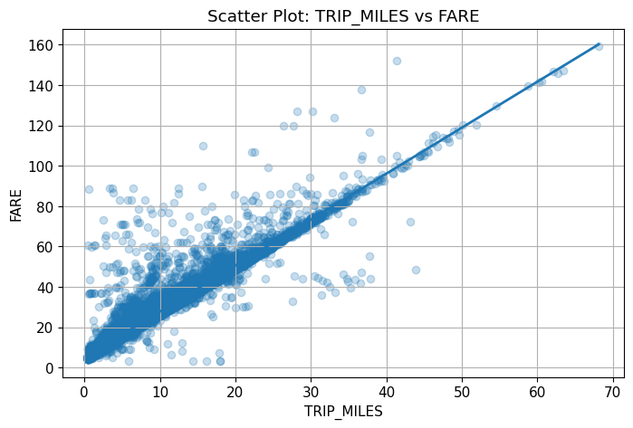

```python
# =========================
# 4. 산점도 1: TRIP_MILES와 FARE
# =========================

plt.figure()
plt.scatter(taxi["TRIP_MILES"], taxi["FARE"], alpha=0.25)

# 전체 데이터 기준 단순 회귀선 시각화
line_model_miles = LinearRegression()
line_model_miles.fit(taxi[["TRIP_MILES"]], taxi["FARE"])
x_line = pd.DataFrame(
    np.linspace(taxi["TRIP_MILES"].min(), taxi["TRIP_MILES"].max(), 100),
    columns=["TRIP_MILES"]
)
y_line = line_model_miles.predict(x_line)
plt.plot(x_line, y_line, linewidth=2)

plt.xlabel("TRIP_MILES")
plt.ylabel("FARE")
plt.title("Scatter Plot: TRIP_MILES vs FARE")
plt.show()
```

## 산점도 2: TRIP_SECONDS와 FARE

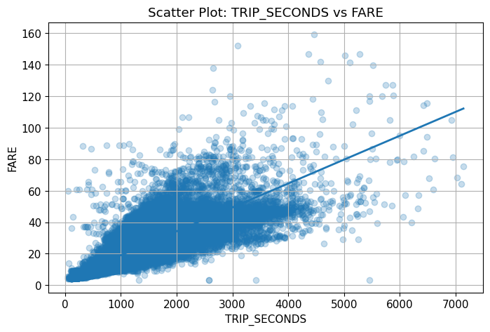

```python
# =========================
# 5. 산점도 2: TRIP_SECONDS와 FARE
# =========================

plt.figure()
plt.scatter(taxi["TRIP_SECONDS"], taxi["FARE"], alpha=0.25)

# 전체 데이터 기준 단순 회귀선 시각화
line_model_seconds = LinearRegression()
line_model_seconds.fit(taxi[["TRIP_SECONDS"]], taxi["FARE"])
x_line = pd.DataFrame(
    np.linspace(taxi["TRIP_SECONDS"].min(), taxi["TRIP_SECONDS"].max(), 100),
    columns=["TRIP_SECONDS"]
)
y_line = line_model_seconds.predict(x_line)
plt.plot(x_line, y_line, linewidth=2)

plt.xlabel("TRIP_SECONDS")
plt.ylabel("FARE")
plt.title("Scatter Plot: TRIP_SECONDS vs FARE")
plt.show()
```

## Correlation Matrix 출력

```
Correlation Matrix
```

|  | TRIP_MILES | TRIP_SECONDS | FARE |
| --- | --- | --- | --- |
| TRIP_MILES | 1.000000 | 0.800855 | 0.975344 |
| TRIP_SECONDS | 0.800855 | 1.000000 | 0.830292 |
| FARE | 0.975344 | 0.830292 | 1.000000 |

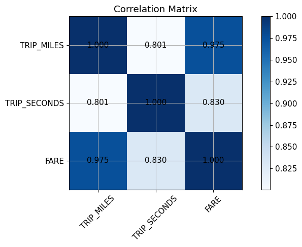

```python
# =========================
# 6. Correlation Matrix 출력
# =========================

corr_matrix = taxi[["TRIP_MILES", "TRIP_SECONDS", "FARE"]].corr()

print("Correlation Matrix")
display(corr_matrix)

plt.figure()
plt.imshow(corr_matrix, cmap="Blues")
plt.colorbar()

plt.xticks(range(len(corr_matrix.columns)), corr_matrix.columns, rotation=45)
plt.yticks(range(len(corr_matrix.columns)), corr_matrix.columns)

for i in range(len(corr_matrix.columns)):
    for j in range(len(corr_matrix.columns)):
        plt.text(j, i, f"{corr_matrix.iloc[i, j]:.3f}",
                 ha="center", va="center")

plt.title("Correlation Matrix")
plt.tight_layout()
plt.show()
```

```python
# =========================
# 7. VIF 계산
# =========================
# VIF = 1 / (1 - R^2)
# 독립변수 간 다중공선성 정도를 확인하기 위해 계산한다.
# 일반적으로 VIF가 5 이상이면 주의, 10 이상이면 심각한 다중공선성으로 본다.

def calculate_vif(df_features):
    vif_result = []

    for target_col in df_features.columns:
        other_cols = [col for col in df_features.columns if col != target_col]

        model = LinearRegression()
        model.fit(df_features[other_cols], df_features[target_col])

        r_squared = model.score(df_features[other_cols], df_features[target_col])
        vif = 1 / (1 - r_squared)

        vif_result.append({
            "Feature": target_col,
            "R_squared_with_other_features": r_squared,
            "VIF": vif
        })

    return pd.DataFrame(vif_result)

vif_df = calculate_vif(taxi[["TRIP_MILES", "TRIP_SECONDS"]])
display(vif_df)
```

|  | Feature | R_squared_with_other_features | VIF |
| --- | --- | --- | --- |
| 0 | TRIP_MILES | 0.641369 | 2.788383 |
| 1 | TRIP_SECONDS | 0.641369 | 2.788383 |

```python
# =========================
# 8. 학습 데이터와 테스트 데이터 분리
# =========================

X_miles = taxi[["TRIP_MILES"]]
X_seconds = taxi[["TRIP_SECONDS"]]
X_multi = taxi[["TRIP_MILES", "TRIP_SECONDS"]]
y = taxi["FARE"]

# 세 모델을 공정하게 비교하기 위해 같은 train/test index를 사용
train_idx, test_idx = train_test_split(
    taxi.index,
    test_size=0.2,
    random_state=42
)

X_miles_train = X_miles.loc[train_idx]
X_miles_test = X_miles.loc[test_idx]

X_seconds_train = X_seconds.loc[train_idx]
X_seconds_test = X_seconds.loc[test_idx]

X_multi_train = X_multi.loc[train_idx]
X_multi_test = X_multi.loc[test_idx]

y_train = y.loc[train_idx]
y_test = y.loc[test_idx]

print("Train size:", len(train_idx))
print("Test size:", len(test_idx))
```

```
Train size: 25355
Test size: 6339
```

## 모델 학습 및 평가 함수

```python
# =========================
# 9. 모델 학습 및 평가 함수
# =========================

def train_and_evaluate(model_name, X_train, X_test, y_train, y_test):
    model = LinearRegression()
    model.fit(X_train, y_train)

    y_pred = model.predict(X_test)
    rmse = np.sqrt(mean_squared_error(y_test, y_pred))

    print("=" * 70)
    print(model_name)
    print("Features:", list(X_train.columns))
    print("Weights:", model.coef_)
    print("Bias:", model.intercept_)
    print("RMSE:", rmse)

    return model, y_pred, rmse

model_miles, pred_miles, rmse_miles = train_and_evaluate(
    "Simple Linear Regression: TRIP_MILES -> FARE",
    X_miles_train, X_miles_test, y_train, y_test
)

model_seconds, pred_seconds, rmse_seconds = train_and_evaluate(
    "Simple Linear Regression: TRIP_SECONDS -> FARE",
    X_seconds_train, X_seconds_test, y_train, y_test
)

model_multi, pred_multi, rmse_multi = train_and_evaluate(
    "Multiple Linear Regression: TRIP_MILES + TRIP_SECONDS -> FARE",
    X_multi_train, X_multi_test, y_train, y_test
)
```

```
======================================================================
Simple Linear Regression: TRIP_MILES -> FARE
Features: ['TRIP_MILES']
Weights: [2.27512707]
Bias: 5.0385863798335215
RMSE: 3.850787647705428
======================================================================
Simple Linear Regression: TRIP_SECONDS -> FARE
Features: ['TRIP_SECONDS']
Weights: [0.0151038]
Bias: 3.9493209740808517
RMSE: 9.65516741972911
======================================================================
Multiple Linear Regression: TRIP_MILES + TRIP_SECONDS -> FARE
Features: ['TRIP_MILES', 'TRIP_SECONDS']
Weights: [2.01634244 0.00251816]
Bias: 3.857050051628839
RMSE: 3.604573310457072
```

## 회귀식 출력

```python
# =========================
# 10. 회귀식 출력
# =========================

print("1) TRIP_MILES 단순 선형회귀식")
print(f"FARE = {model_miles.coef_[0]:.4f} * TRIP_MILES + {model_miles.intercept_:.4f}")

print("\n2) TRIP_SECONDS 단순 선형회귀식")
print(f"FARE = {model_seconds.coef_[0]:.4f} * TRIP_SECONDS + {model_seconds.intercept_:.4f}")

print("\n3) TRIP_MILES + TRIP_SECONDS 다중 선형회귀식")
print(
    f"FARE = {model_multi.coef_[0]:.4f} * TRIP_MILES "
    f"+ {model_multi.coef_[1]:.4f} * TRIP_SECONDS "
    f"+ {model_multi.intercept_:.4f}"
)
```

```
1) TRIP_MILES 단순 선형회귀식
FARE = 2.2751 * TRIP_MILES + 5.0386

2) TRIP_SECONDS 단순 선형회귀식
FARE = 0.0151 * TRIP_SECONDS + 3.9493

3) TRIP_MILES + TRIP_SECONDS 다중 선형회귀식
FARE = 2.0163 * TRIP_MILES + 0.0025 * TRIP_SECONDS + 3.8571
```

## RMSE 비교

|  | Model | Regression Type | RMSE |
| --- | --- | --- | --- |
| 0 | TRIP_MILES only | Simple Linear Regression | 3.850788 |
| 1 | TRIP_SECONDS only | Simple Linear Regression | 9.655167 |
| 2 | TRIP_MILES + TRIP_SECONDS | Multiple Linear Regression | 3.604573 |

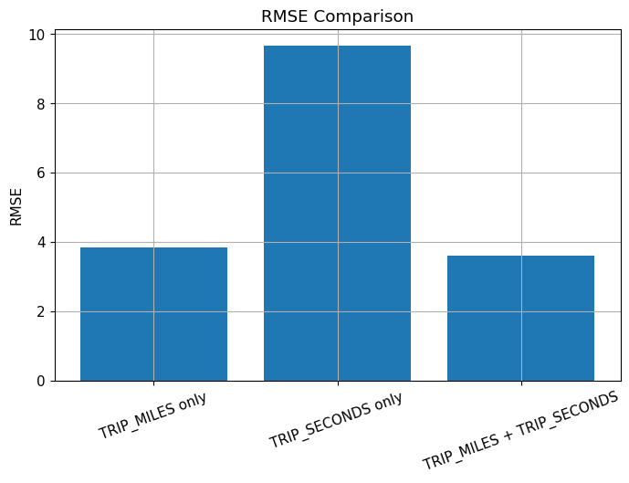

```python
# =========================
# 11. RMSE 비교
# =========================

result_df = pd.DataFrame({
    "Model": [
        "TRIP_MILES only",
        "TRIP_SECONDS only",
        "TRIP_MILES + TRIP_SECONDS"
    ],
    "Regression Type": [
        "Simple Linear Regression",
        "Simple Linear Regression",
        "Multiple Linear Regression"
    ],
    "RMSE": [
        rmse_miles,
        rmse_seconds,
        rmse_multi
    ]
})

display(result_df)

plt.figure()
plt.bar(result_df["Model"], result_df["RMSE"])
plt.ylabel("RMSE")
plt.title("RMSE Comparison")
plt.xticks(rotation=20)
plt.show()
```

```python
# =========================
# 12. 실제값과 예측값 비교 일부 출력
# =========================

comparison_df = pd.DataFrame({
    "Actual FARE": y_test.values,
    "Predicted by TRIP_MILES": pred_miles,
    "Predicted by TRIP_SECONDS": pred_seconds,
    "Predicted by BOTH": pred_multi
})

display(comparison_df.head(10))
```

|  | Actual FARE | Predicted by TRIP_MILES | Predicted by TRIP_SECONDS | Predicted by BOTH |
| --- | --- | --- | --- | --- |
| 0 | 14.84 | 15.640679 | 19.309887 | 15.814179 |
| 1 | 4.75 | 6.426414 | 6.154476 | 5.454671 |
| 2 | 33.50 | 34.888253 | 22.300440 | 33.371033 |
| 3 | 23.00 | 23.762882 | 22.270232 | 23.506082 |
| 4 | 9.68 | 9.588841 | 14.990200 | 9.730513 |
| 5 | 46.25 | 45.990874 | 32.948620 | 44.986090 |
| 6 | 9.75 | 10.680902 | 13.887622 | 10.514532 |
| 7 | 11.75 | 9.588841 | 23.886339 | 11.213712 |
| 8 | 58.71 | 46.514153 | 30.350766 | 45.016725 |
| 9 | 8.00 | 8.633287 | 12.331931 | 8.440453 |

## 결과 해석

### 1. 산점도 해석

`TRIP_MILES`와 `FARE`의 산점도에서는 주행거리가 증가할수록 요금도 함께 증가하는 뚜렷한 양의 선형관계가 나타났다. 점들이 회귀선 주변에 비교적 밀집되어 있으므로, 주행거리는 택시 요금을 설명하는 핵심 변수라고 볼 수 있다.

`TRIP_SECONDS`와 `FARE` 역시 양의 관계를 보였지만, 같은 주행시간에서도 요금이 넓게 퍼져 있었다. 따라서 주행시간만으로 요금을 예측하는 모델은 주행거리 기반 모델보다 예측 오차가 클 가능성이 높다.

### 2. 회귀계수와 편향 해석

`TRIP_MILES`만 사용한 단순 선형회귀식은 다음과 같다.

`FARE = 2.2751 × TRIP_MILES + 5.0386`

이는 주행거리가 1마일 증가할 때 요금이 평균적으로 약 2.2751 증가한다는 의미이다. 편향 5.0386은 기본요금에 가까운 값으로 해석할 수 있다.

`TRIP_SECONDS`만 사용한 단순 선형회귀식은 다음과 같다.

`FARE = 0.0151 × TRIP_SECONDS + 3.9493`

즉, 주행시간이 1초 증가할 때 요금은 평균적으로 약 0.0151 증가한다. 초 단위 변수이기 때문에 계수 값은 작게 나타난다.

두 변수를 함께 사용한 다중 선형회귀식은 다음과 같다.

`FARE = 2.0163 × TRIP_MILES + 0.0025 × TRIP_SECONDS + 3.8571`

다중회귀에서는 다른 변수를 통제한 상태에서 각 변수의 영향을 해석한다. 따라서 `TRIP_MILES`의 계수 2.0163은 주행시간이 동일할 때 주행거리 1마일 증가에 따른 요금 증가량이고, `TRIP_SECONDS`의 계수 0.0025는 주행거리가 동일할 때 주행시간 1초 증가에 따른 요금 증가량이다.

### 3. Correlation Matrix와 다중공선성 해석

Correlation Matrix에서 `TRIP_MILES`와 `FARE`의 상관계수는 약 0.975로 매우 높았다. 반면 `TRIP_SECONDS`와 `FARE`의 상관계수는 약 0.830으로, 양의 상관관계는 있지만 주행거리보다 낮았다. 이를 통해 요금 예측에는 주행시간보다 주행거리가 더 직접적인 영향을 주는 변수임을 확인할 수 있다.

또한 `TRIP_MILES`와 `TRIP_SECONDS` 사이의 상관계수는 약 0.801로 비교적 높게 나타났다. 즉, 두 독립변수는 서로 관련된 정보를 일부 공유하므로 다중공선성 가능성이 있다. 그러나 VIF 값은 약 2.79로, 일반적으로 심각한 다중공선성 기준인 5 또는 10보다 낮다. 따라서 심각한 다중공선성 문제는 아니지만, 두 변수가 유사한 정보를 일부 설명하기 때문에 회귀계수에는 영향을 줄 수 있다.

실제로 `TRIP_MILES`만 사용했을 때 계수는 2.2751이었지만, `TRIP_SECONDS`를 함께 사용한 다중회귀에서는 2.0163으로 감소하였다. 이는 단순회귀에서 주행거리가 단독으로 설명하던 요금 변동의 일부를 주행시간 변수가 함께 설명했기 때문이다.

### 4. RMSE 비교 해석

RMSE는 예측값과 실제값 사이의 평균적인 오차 크기를 의미하며, 값이 작을수록 예측 성능이 좋다.

세 모델의 RMSE는 다음과 같다.

| 모델 | RMSE |
| --- | --- |
| `TRIP_MILES` only | 3.8508 |
| `TRIP_SECONDS` only | 9.6552 |
| `TRIP_MILES + TRIP_SECONDS` | 3.6046 |

`TRIP_SECONDS`만 사용한 모델은 RMSE가 9.6552로 가장 컸고, `TRIP_MILES`만 사용한 모델은 RMSE가 3.8508로 훨씬 낮았다. 따라서 주행시간보다 주행거리가 요금 예측에 더 적합한 변수임을 알 수 있다.

가장 좋은 성능은 `TRIP_MILES`와 `TRIP_SECONDS`를 함께 사용한 다중 선형회귀 모델에서 나타났으며, RMSE는 3.6046이었다. 다만 `TRIP_MILES` 단독 모델과의 차이가 크지는 않기 때문에, 이 데이터에서는 주행거리가 요금 예측의 대부분을 설명하고, 주행시간은 추가적인 보조 정보를 제공한다고 해석할 수 있다.